# GESIS CSS strategy development

Bennett Kleinberg

20 Sept. 2022

Long-term vision

## Research excellence

Impact through world-leading research.

- fundamental, methodological questions
- topical questions
- from exploring and describing to **understanding**
  - CSS theories
  - psychometrics of digital behavioural data

## Outstanding services

World-leading research through outstanding services.

- capacities beyond single university efforts
- closing the gap between disciplines
- breaking down the infrastructural barriers
  - data access
  - available methods
  - knowledge transfer

Achieving this vision

## Setting a goal

What is the goal of CSS?

… that makes GESIS unique?

## A moonshot goal

(Very) ambitious goal that guides ($\neq$ determines) all efforts.

- common in other disciplines (medicine, public health), industry and transnational bodies (UN Sustainable Development Goals)
- but practically absent in social science research

Examples: “end malnutrition by 2030”, “doubling cancer survival”

CSS can be bold.

## 1. A CSS moonshot goal

**Understanding the nexus between offline and online human behaviour.**

Implies:

- new funding (macro and micro) for internal teams to contribute to this goal
- alignment of staff recruitment toward that goal
- make the overarching goal the identifying and distinguishing characteristic of CSS at GESIS
- the existing structures are an excellent starting point to make bold moves

## 2. Wild ideas

Most undervalued resource: seemingly pointless ideas.

- traditional model is hostile to wild ideas
- but: many wild ideas are not so pointless in hindsight

Proposal:

- central part of CSS: the Wild Ideas Lab
- unbureaucratic access to time and funding
- work on wild ideas with minimal oversight

Example: exploring a new method for 1 day/week for 3 months with a student assistant.

## 3. Service incubator

The service mission is a pillar of CSS.

- a dual task load (research + services) is a delicate balancing act for teams and individuals

Proposal:

- more attention to services with a CSS Service Incubator
- equal to pure research teams but as an in-house start-up
- full dedication to the professionalisation of services (video portals, course material, software)
- close collaboration with research teams

## 4. Behavioural inference team

Human behaviour is the key frontier for CSS.

- digital behavioural data are exciting but (very) challenging
- needs a dedicated focus

Proposal:

- new research team on “behavioural inference”
- closely aligned to social science methods (experiments)
- using the *integrative modelling approach*

## Structure after proposal

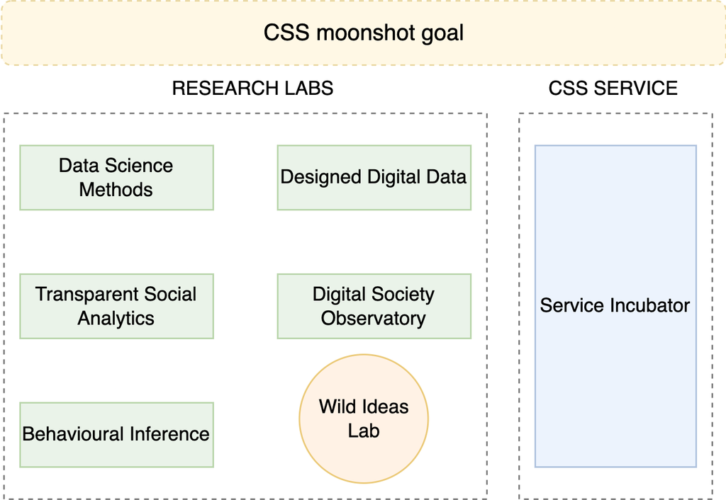

## 5. Talent development

Talent is the one most valuable resource for CSS.

Proposal:

- fostering talent through ambition-based development
- harnessing wild ideas
- talent as the stakeholder of GESIS

## Do we even need CSS?

Yes. But not because it’s a fascinating area to work on.

More important: *CSS can solve the hard societal problems*

The ultimate goal of CSS must be social impact.

Full commitment to the two most precious resources:

**ideas + talent**

## Thanks.

- bennett.kleinberg@tilburguniversity.edu
- https://bkleinberg.net/